# SDS496_HW9

Problem 1. Download the Covid-19 data set under Modules on Canvas. The data set measures the incident rate of Covid-19 across 3202 US administrative units along with their longitude and latitude.

```python
# File paths
import pandas as pd
covid_path = '/Users/aidanashrafi/Downloads/COVID-19_Cases_US.csv'
track_path = '/Users/aidanashrafi/Downloads/track.txt'
diabetes_path = '/Users/aidanashrafi/Downloads/diabetes.txt'
cancer_path = '/Users/aidanashrafi/Downloads/wdbc.txt'

diabetes_data = pd.read_csv(diabetes_path, delimiter=" ")
track_data = pd.read_csv(track_path, delimiter=" ")
cancer_data = pd.read_csv(cancer_path, delimiter=" ")

# Reading CSV file
covid_data = pd.read_csv(covid_path)
```

i. Determine a transformation of incident rate which appears to be symmetrically distributed.

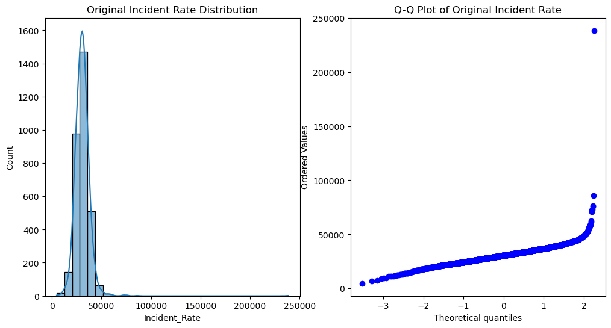

```python
import numpy as np
import matplotlib.pyplot as plt
import seaborn as sns
from scipy.stats import probplot, boxcox

# Inspect the original incident rate distribution
incident_rate = covid_data['Incident_Rate']

# Plot histogram and Q-Q plot for original data
plt.figure(figsize=(12, 6))
plt.subplot(1, 2, 1)
sns.histplot(incident_rate, kde=True, bins=30)
plt.title("Original Incident Rate Distribution")

plt.subplot(1, 2, 2)
probplot(incident_rate, dist="norm", plot=plt)
plt.title("Q-Q Plot of Original Incident Rate")
plt.show()
```

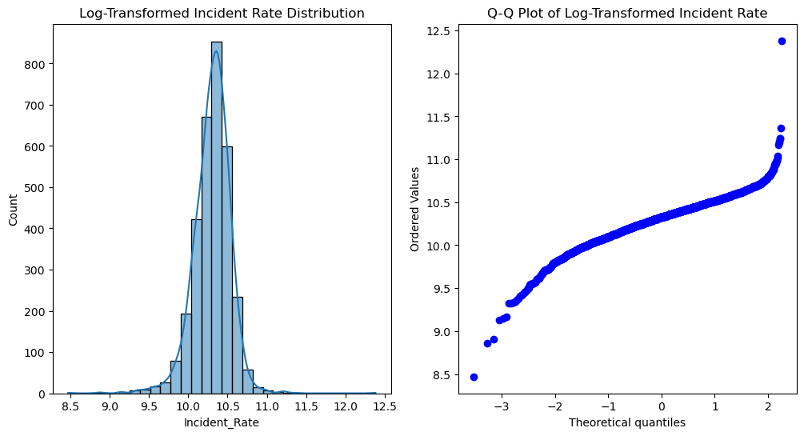

```python
# Apply log transformation (add small constant to avoid log(0))
log_transformed = np.log1p(incident_rate)

# Plot histogram and Q-Q plot for log-transformed data
plt.figure(figsize=(12, 6))
plt.subplot(1, 2, 1)
sns.histplot(log_transformed, kde=True, bins=30)
plt.title("Log-Transformed Incident Rate Distribution")

plt.subplot(1, 2, 2)
probplot(log_transformed, dist="norm", plot=plt)
plt.title("Q-Q Plot of Log-Transformed Incident Rate")
plt.show()
```

The log transformation of incident rate appears to be symmetric.

ii. Randomly select 20% of the administrative units. Plot the latitude against the longitude of your subset of administrative units where the size of each point is proportional to the magnitude of its transformed incident rate. Does your plot resemble the US map? Do nearby administrative units display similarly sized points?

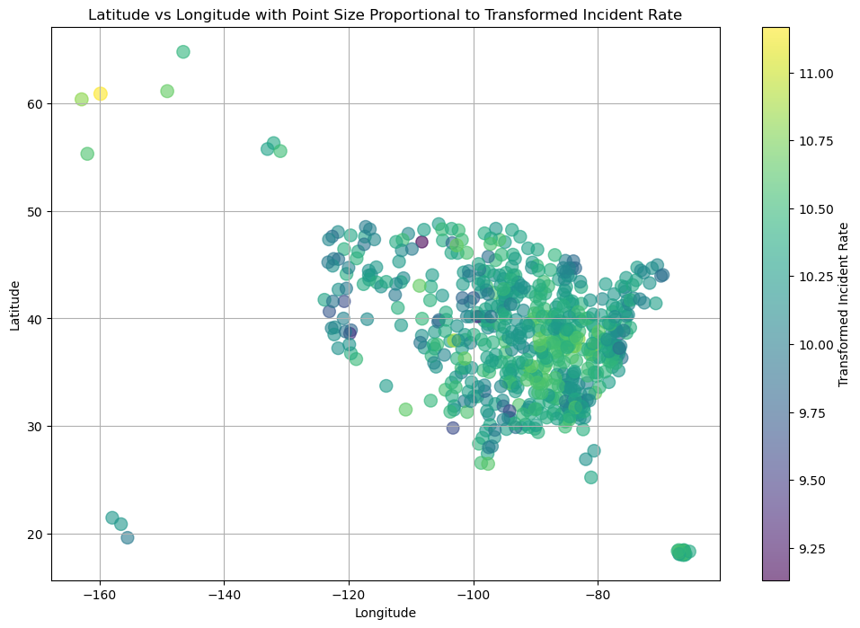

```python
import matplotlib.pyplot as plt
import numpy as np

# Step 1: Randomly select 20% of the administrative units
subset_covid_data = covid_data.sample(frac=0.2, random_state=42)

# Extract latitude, longitude, and transformed incident rate for the subset
latitudes = subset_covid_data['Lat']
longitudes = subset_covid_data['Long_']
transformed_rate = np.log1p(subset_covid_data['Incident_Rate'])  # Using log-transformed rate

# Step 2: Plot latitude vs. longitude
plt.figure(figsize=(12, 8))
plt.scatter(
    longitudes, latitudes,
    s=transformed_rate * 10,  # Scale the size for visibility
    alpha=0.6,
    c=transformed_rate,  # Color by transformed incident rate
    cmap='viridis'
)
plt.colorbar(label='Transformed Incident Rate')
plt.title('Latitude vs Longitude with Point Size Proportional to Transformed Incident Rate')
plt.xlabel('Longitude')
plt.ylabel('Latitude')
plt.grid(True)
plt.show()
```

The plot does look like the US map. Nearby administrative units display similarly sized points.

iii. Split your subset of administrative units into a training set and a test set. Fit a Gaussian process regression model on the training set. Calculate the mean squared prediction error of your model on the test set and compare it against that of a null model with no covariance structure.

```python
from sklearn.model_selection import train_test_split
from sklearn.gaussian_process import GaussianProcessRegressor
from sklearn.gaussian_process.kernels import RBF, ConstantKernel as C
from sklearn.metrics import mean_squared_error
import numpy as np

# Step 1: Split the subset into training and test sets
X = subset_covid_data[['Lat', 'Long_']]  # Latitude and Longitude as predictors
y = np.log1p(subset_covid_data['Incident_Rate'])

# Step 1: Drop rows with missing values
valid_rows = X.notnull().all(axis=1) & y.notnull()
X = X[valid_rows]
y = y[valid_rows]

# Step 2: Split the subset into training and test sets
X_train, X_test, y_train, y_test = train_test_split(X, y, test_size=0.3, random_state=42)

# Step 3: Fit a Gaussian Process Regression model
# Define kernel (RBF kernel with a constant term)
kernel = C(1.0, (1e-3, 1e3)) * RBF(length_scale=1.0, length_scale_bounds=(1e-3, 1e3))
gpr = GaussianProcessRegressor(kernel=kernel, n_restarts_optimizer=10, random_state=42)

# Fit the model on training data
gpr.fit(X_train, y_train)

# Predict on test set
y_pred = gpr.predict(X_test)
```

```python
# Step 4: Calculate MSPE for GPR model
mspe_gpr = mean_squared_error(y_test, y_pred)
print(f"Mean Squared Prediction Error (GPR): {mspe_gpr}")

# Step 5: Null model (predicting the mean)
y_null_pred = np.full_like(y_test, y_train.mean())  # Predict mean of training labels
mspe_null = mean_squared_error(y_test, y_null_pred)
print(f"Mean Squared Prediction Error (Null Model): {mspe_null}")

# Comparison
print(f"Improvement over Null Model: {mspe_null - mspe_gpr}")
```

```
Mean Squared Prediction Error (GPR): 8.71722749442318
Mean Squared Prediction Error (Null Model): 0.04562319257402795
Improvement over Null Model: -8.67160430184915
```

Mean Squared Prediction Error (GPR): 8.71722749442318

Mean Squared Prediction Error (Null Model): 0.04562319257402795

Improvement over Null Model: -8.67160430184915

Problem 2. Download the track data set under Modules on Canvas. The data set measures women’s national track records on 3 short-distance (100m, 200m, 400m), 2 medium-distance (800m, 1500m) and 2 long-distance (3000m, Marathon) track events for 54 countries.

i. Create a correlation matrix and a scatterplot matrix of the track events. Is there strong collinearity?

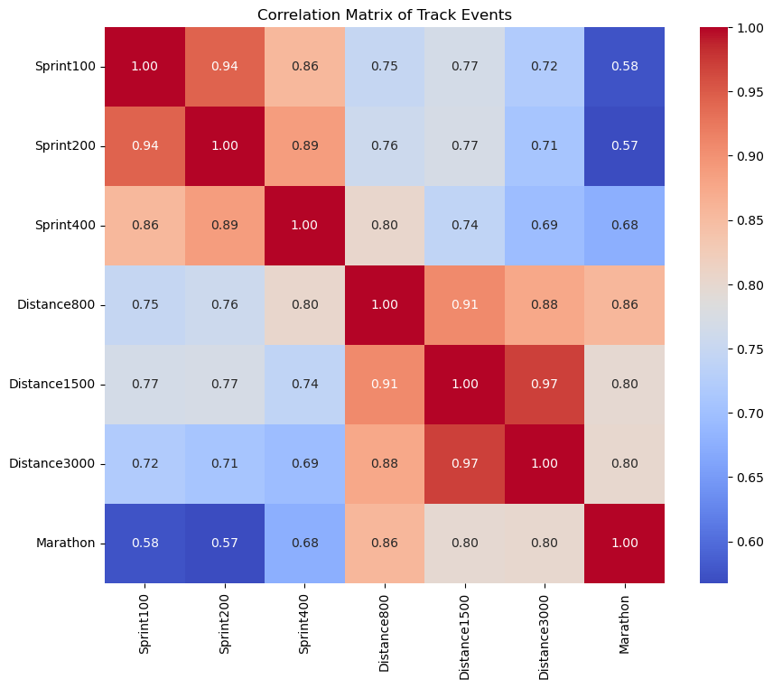

```python
import seaborn as sns
import matplotlib.pyplot as plt

# Step 1: Extract track event columns (assuming relevant columns are already identified)
# Adjust column names based on the actual dataset structure
track_events = track_data[['Sprint100', 'Sprint200', 'Sprint400', 'Distance800', 'Distance1500', 'Distance3000', 'Marathon']]

# Step 2: Compute correlation matrix
correlation_matrix = track_events.corr()

# Step 3: Plot the correlation matrix
plt.figure(figsize=(10, 8))
sns.heatmap(correlation_matrix, annot=True, fmt=".2f", cmap='coolwarm', cbar=True)
plt.title("Correlation Matrix of Track Events")
plt.show()
```

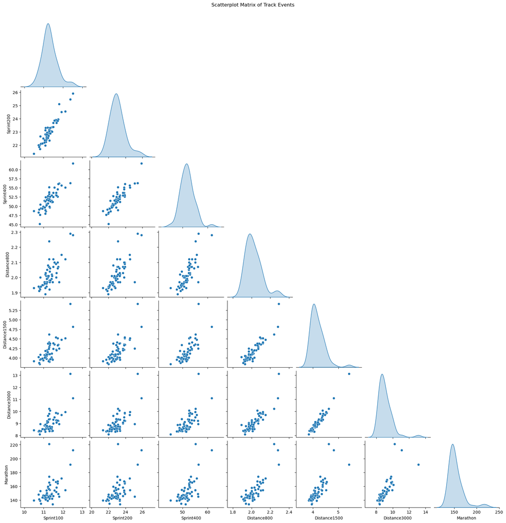

```python
# Step 4: Create a scatterplot matrix
sns.pairplot(track_events, diag_kind="kde", corner=True)
plt.suptitle("Scatterplot Matrix of Track Events", y=1.02)
plt.show()
```

Yes, there is strong collinearity.

ii. Create boxplots of the track events. Do they display the same amount of variation?

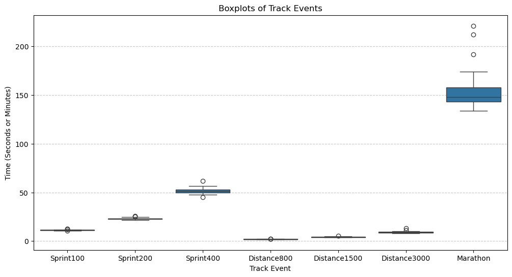

```python
import seaborn as sns
import matplotlib.pyplot as plt

# Step 1: Reshape data for easier plotting
# Assuming the track event columns are named as shown
track_events = track_data[['Sprint100', 'Sprint200', 'Sprint400', 'Distance800', 'Distance1500', 'Distance3000', 'Marathon']]
track_events_melted = track_events.melt(var_name="Event", value_name="Time")

# Step 2: Create boxplots
plt.figure(figsize=(12, 6))
sns.boxplot(x="Event", y="Time", data=track_events_melted)
plt.title("Boxplots of Track Events")
plt.xlabel("Track Event")
plt.ylabel("Time (Seconds or Minutes)")
plt.grid(axis='y', linestyle='--', alpha=0.7)
plt.show()
```

No, marathon shows an extreme variation compared to the rest of the events.

iii. Based on your answer to the previous part, apply a suitable principal components analysis on the track events and provide the corresponding scree plot. What percentage of the total variation does each of the first 2 principal components explain? What’s an appropriate choice for the number of principal components?

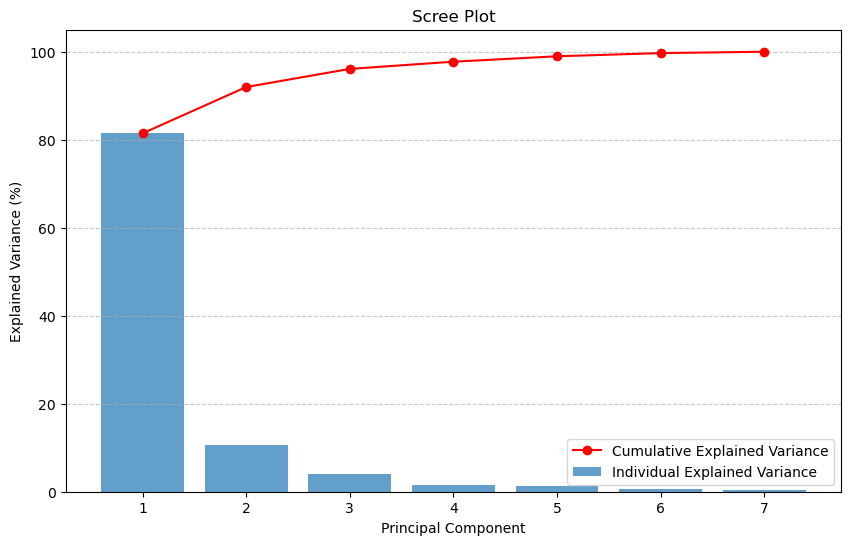

```python
from sklearn.decomposition import PCA
from sklearn.preprocessing import StandardScaler
import numpy as np
import matplotlib.pyplot as plt

# Step 1: Extract and standardize the track event data
track_events = track_data[['Sprint100', 'Sprint200', 'Sprint400', 'Distance800', 'Distance1500', 'Distance3000', 'Marathon']]
scaler = StandardScaler()
track_events_scaled = scaler.fit_transform(track_events)

# Step 2: Perform PCA
pca = PCA()
pca.fit(track_events_scaled)

# Step 3: Scree Plot
explained_variance = pca.explained_variance_ratio_ * 100  # Convert to percentage
cumulative_variance = np.cumsum(explained_variance)

plt.figure(figsize=(10, 6))
plt.bar(range(1, len(explained_variance) + 1), explained_variance, alpha=0.7, label='Individual Explained Variance')
plt.plot(range(1, len(cumulative_variance) + 1), cumulative_variance, marker='o', color='r', label='Cumulative Explained Variance')
plt.title("Scree Plot")
plt.xlabel("Principal Component")
plt.ylabel("Explained Variance (%)")
plt.legend()
plt.grid(axis='y', linestyle='--', alpha=0.7)
plt.show()
```

```python
# Step 4: Extract the variance explained by the first two components
pc1_variance = explained_variance[0]
pc2_variance = explained_variance[1]
total_variance = cumulative_variance[1]  # First two components' cumulative variance

print(f"Percentage of Total Variation Explained by PC1: {pc1_variance:.2f}%")
print(f"Percentage of Total Variation Explained by PC2: {pc2_variance:.2f}%")
print(f"Cumulative Variation by First Two PCs: {total_variance:.2f}%")
```

```
Percentage of Total Variation Explained by PC1: 81.45%
Percentage of Total Variation Explained by PC2: 10.53%
Cumulative Variation by First Two PCs: 91.97%
```

91.97% of the cumulative variation is explained by the first two PCs. Using 3 PCs seems appropriate as it explains over 95% of the cumulative variation in the model.

iv. Create a barplot and a scatterplot for the loadings of the first 2 principal components. How can these principal components be interpreted in terms of the track events based on their loadings?

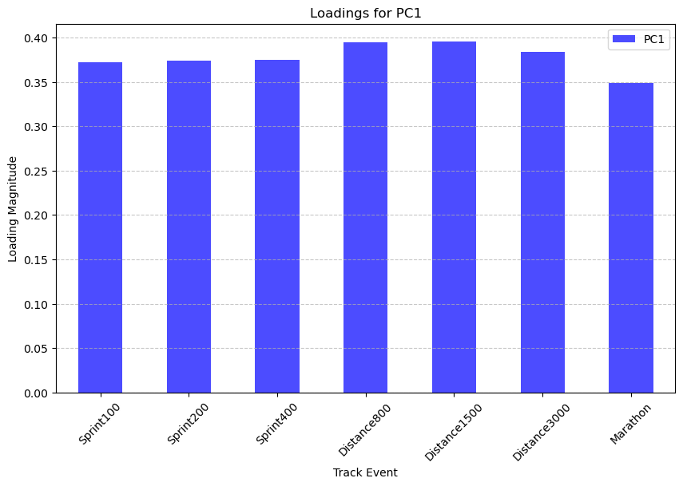

```python
import pandas as pd
import matplotlib.pyplot as plt

# Step 1: Extract loadings (coefficients of the original variables for the PCs)
loadings = pd.DataFrame(
    pca.components_.T,  # Transpose to match features to PCs
    columns=[f"PC{i+1}" for i in range(pca.n_components_)],
    index=track_events.columns
)

# Step 2: Barplot for PC1 and PC2 loadings
plt.figure(figsize=(10, 6))
loadings['PC1'].plot(kind='bar', alpha=0.7, color='b', label='PC1')
plt.title('Loadings for PC1')
plt.xlabel('Track Event')
plt.ylabel('Loading Magnitude')
plt.xticks(rotation=45)
plt.grid(axis='y', linestyle='--', alpha=0.7)
plt.legend()
plt.show()
```

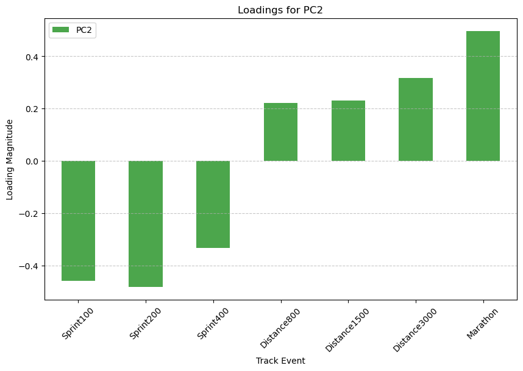

```python
plt.figure(figsize=(10, 6))
loadings['PC2'].plot(kind='bar', alpha=0.7, color='g', label='PC2')
plt.title('Loadings for PC2')
plt.xlabel('Track Event')
plt.ylabel('Loading Magnitude')
plt.xticks(rotation=45)
plt.grid(axis='y', linestyle='--', alpha=0.7)
plt.legend()
plt.show()
```

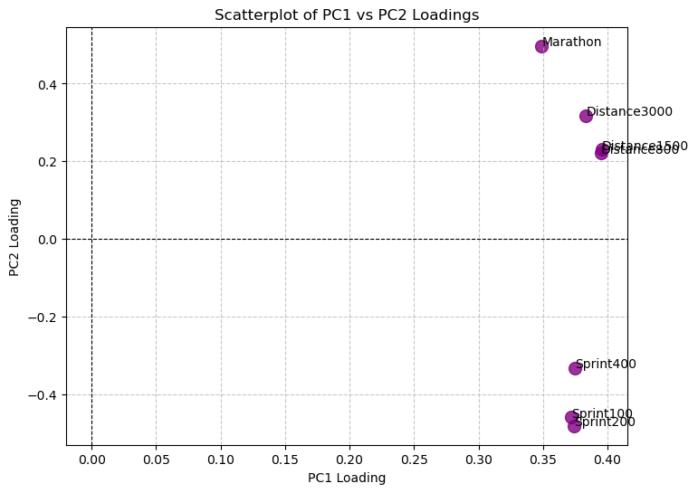

```python
# Step 3: Scatterplot of PC1 vs. PC2 loadings
plt.figure(figsize=(8, 6))
plt.scatter(loadings['PC1'], loadings['PC2'], s=100, alpha=0.8, color='purple')
for i, feature in enumerate(loadings.index):
    plt.text(loadings['PC1'][i], loadings['PC2'][i], feature, fontsize=10)
plt.title("Scatterplot of PC1 vs PC2 Loadings")
plt.xlabel("PC1 Loading")
plt.ylabel("PC2 Loading")
plt.axhline(0, color='black', linestyle='--', linewidth=0.8)
plt.axvline(0, color='black', linestyle='--', linewidth=0.8)
plt.grid(True, linestyle='--', alpha=0.7)
plt.show()
```

Each loading represents how much a specific track event contributes to the principal component. Larger absolute values (positive or negative) indicate stronger contributions. Positive and negative loadings may capture opposing trends. For example, if some short-distance events have positive loadings and others have negative loadings, the component might differentiate between countries excelling in one category versus another. Events where better performance (lower times) leads to higher component scores. Events where worse performance (higher times) leads to lower component scores, or a trade-off between events.

v. Create a scatterplot for the scores of the first 2 principal components labeled by country. Which countries appear to have the overall higher and lower track records? Which countries appear to excel in short-distance track events and which appear to excel in long-distance track events? What’s the correlation between the scores of the first 2 principal components?

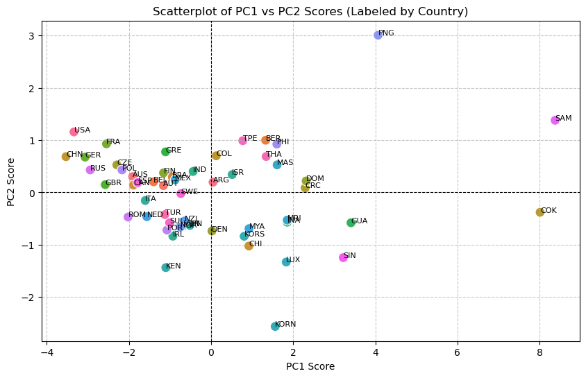

```
Correlation between PC1 and PC2 Scores: -0.00 (p-value: 1.000)
```

```python
import matplotlib.pyplot as plt
import seaborn as sns
import pandas as pd
from scipy.stats import pearsonr

# Step 1: Compute scores for the first two principal components
# Scores = standardized data projected onto the principal components
pc_scores = pd.DataFrame(
    pca.transform(track_events_scaled),  # Projecting onto principal components
    columns=[f"PC{i+1}" for i in range(pca.n_components_)]
)
pc_scores['Country'] = track_data['Country']  # Assuming 'Country' is the column name

# Step 2: Scatterplot for PC1 vs PC2 scores
plt.figure(figsize=(10, 6))
sns.scatterplot(data=pc_scores, x='PC1', y='PC2', hue='Country', legend=False, s=100)

# Annotate countries on the plot
for i in range(pc_scores.shape[0]):
    plt.text(pc_scores['PC1'][i], pc_scores['PC2'][i], pc_scores['Country'][i], fontsize=8)

plt.axhline(0, color='black', linestyle='--', linewidth=0.8)
plt.axvline(0, color='black', linestyle='--', linewidth=0.8)
plt.title("Scatterplot of PC1 vs PC2 Scores (Labeled by Country)")
plt.xlabel("PC1 Score")
plt.ylabel("PC2 Score")
plt.grid(True, linestyle='--', alpha=0.7)
plt.show()

# Step 3: Correlation between PC1 and PC2 scores
correlation, p_value = pearsonr(pc_scores['PC1'], pc_scores['PC2'])
print(f"Correlation between PC1 and PC2 Scores: {correlation:.2f} (p-value: {p_value:.3f})")
```

There is 0 correlation between PC1 and PC2 scores.

vi. Apply a suitable sparse principal components analysis to extract 2 principal components with 4 and 3 non-zero loadings respectively. What percentage of the total variation does each of these sparse principal components explain?

```python
from sklearn.decomposition import SparsePCA
import numpy as np

# Step 1: Define Sparse PCA with two components
sparse_pca = SparsePCA(n_components=2, random_state=42, alpha=1)  # Adjust alpha if needed

# Step 2: Fit Sparse PCA to the track event data
sparse_pca.fit(track_events_scaled)

# Step 3: Extract sparse loadings
sparse_loadings = pd.DataFrame(
    sparse_pca.components_.T,  # Transpose to match features to components
    columns=["SparsePC1", "SparsePC2"],
    index=track_events.columns
)

# Step 4: Calculate explained variance approximation
# Sparse PCA does not directly provide explained variance. Approximate using projections.
sparse_scores = sparse_pca.transform(track_events_scaled)
sparse_explained_variance = np.var(sparse_scores, axis=0) / np.sum(np.var(sparse_scores, axis=0)) * 100

# Display sparse loadings
print("Sparse Loadings (4 non-zero for PC1, 3 non-zero for PC2):")
print(sparse_loadings)
```

[output not shown]

```python
# Step 5: Display explained variance
print(f"Percentage of Total Variation Explained by Sparse PC1: {sparse_explained_variance[0]:.2f}%")
print(f"Percentage of Total Variation Explained by Sparse PC2: {sparse_explained_variance[1]:.2f}%")
print(f"Cumulative Variation Explained: {np.sum(sparse_explained_variance):.2f}%")
```

```
Percentage of Total Variation Explained by Sparse PC1: 54.38%
Percentage of Total Variation Explained by Sparse PC2: 45.62%
Cumulative Variation Explained: 100.00%
```

Percentage of Total Variation Explained by Sparse PC1: 54.38%

Percentage of Total Variation Explained by Sparse PC2: 45.62%

Cumulative Variation Explained: 100.00%

vii. Create a barplot for the loadings of these sparse principal components. How can these principal components be interpreted in terms of the track events based on their loadings?

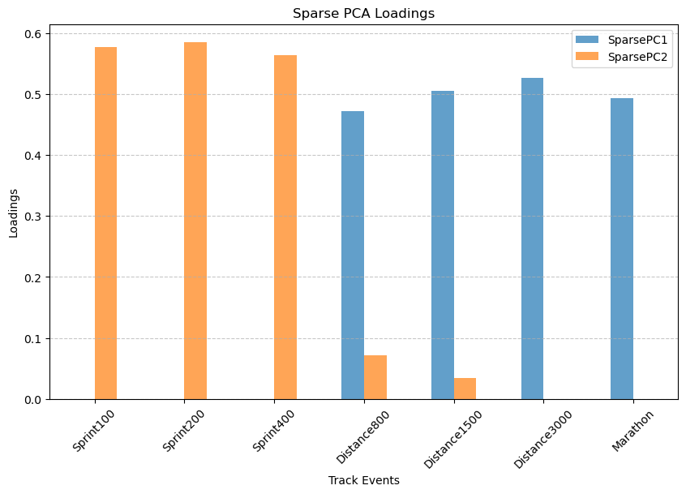

```python
# Step 6: Plot barplot of sparse loadings
sparse_loadings.plot(kind='bar', figsize=(10, 6), alpha=0.7)
plt.title("Sparse PCA Loadings")
plt.xlabel("Track Events")
plt.ylabel("Loadings")
plt.grid(axis='y', linestyle='--', alpha=0.7)
plt.legend(["SparsePC1", "SparsePC2"])
plt.xticks(rotation=45)
plt.show()
```

Each loading represents how much a specific track event contributes to the principal component. Larger absolute values (positive or negative) indicate stronger contributions. Positive and negative loadings may capture opposing trends. For example, if some short-distance events have positive loadings and others have negative loadings, the component might differentiate between countries excelling in one category versus another. Events where better performance (lower times) leads to higher component scores. Events where worse performance (higher times) leads to lower component scores, or a trade-off between events.

Problem 3. Download the diabetes data set under Modules on Canvas. The data set contains measurements on age, sex, 8 clinical measurements and a quantitative measure of disease progression one year after baseline (prog) for 442 diabetes patients. Here’s a brief description for the clinical measurements: • bmi: body mass index • map: mean arterial blood pressure • tc: total cholesterol • ldl: low-density lipoproteins (bad cholesterol) • hdl: high-density lipoproteins (good cholesterol) • tch: ratio of tc over hdl • ltg: log of triglycerides level • glu: blood sugar level

i. Create a correlation matrix and a scatterplot matrix of the clinical measurements. Is there strong collinearity?

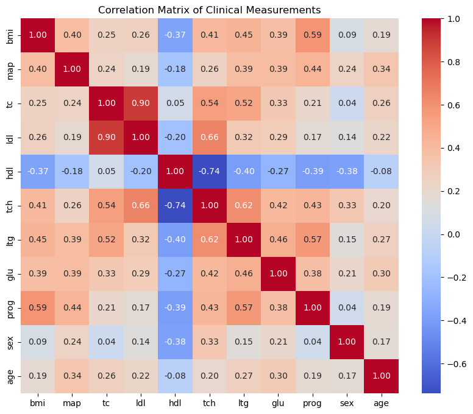

```python
import seaborn as sns
import matplotlib.pyplot as plt

# Step 1: Extract the clinical measurements
clinical_data = diabetes_data[['bmi', 'map', 'tc', 'ldl', 'hdl', 'tch', 'ltg', 'glu', 'prog', 'sex', 'age']]

# Step 2: Calculate the correlation matrix
correlation_matrix = clinical_data.corr()

# Step 3: Plot the correlation matrix
plt.figure(figsize=(10, 8))
sns.heatmap(correlation_matrix, annot=True, fmt=".2f", cmap='coolwarm', cbar=True)
plt.title("Correlation Matrix of Clinical Measurements")
plt.show()
```

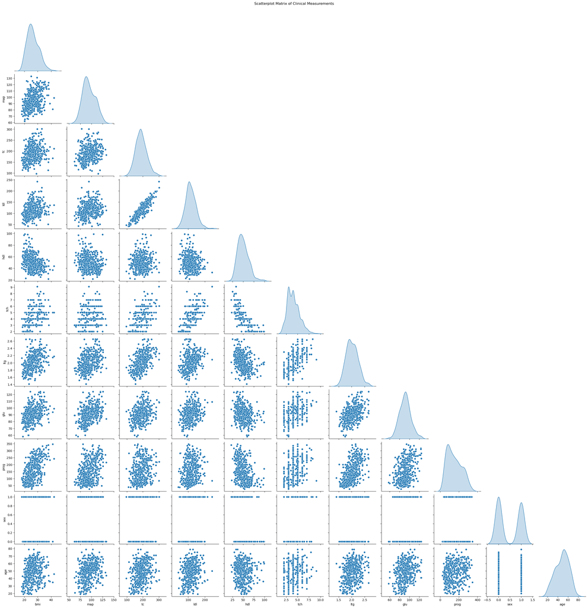

```python
# Step 4: Create a scatterplot matrix
sns.pairplot(clinical_data, diag_kind="kde", corner=True)
plt.suptitle("Scatterplot Matrix of Clinical Measurements", y=1.02)
plt.show()
```

There is collinearity, but it is not as strong as in the last problem.

ii. Split the data set into a training set and a test set. Fit a linear regression model with all available predictors for diabetes progression on the training set. Provide a summary of the regression results and comment on the statistical significance of the estimated regression coefficients. Calculate the mean squared prediction error on the test set.

```python
from sklearn.model_selection import train_test_split
from sklearn.linear_model import LinearRegression
from sklearn.metrics import mean_squared_error
import statsmodels.api as sm
import numpy as np

# Step 1: Split the data into training and test sets
X = diabetes_data[['age', 'sex', 'bmi', 'map', 'tc', 'ldl', 'hdl', 'tch', 'ltg', 'glu']]  # Predictors
y = diabetes_data['prog']  # Target variable

X_train, X_test, y_train, y_test = train_test_split(X, y, test_size=0.3, random_state=42)

# Step 2: Fit a linear regression model using sklearn
lr = LinearRegression()
lr.fit(X_train, y_train)

# Predict on test set
y_pred = lr.predict(X_test)

# Calculate Mean Squared Prediction Error
mspe = mean_squared_error(y_test, y_pred)
print(f"Mean Squared Prediction Error on Test Set: {mspe:.2f}")
```

```
Mean Squared Prediction Error on Test Set: 2821.74
```

```python
# Step 3: Fit a linear regression model using statsmodels for detailed summary
X_train_sm = sm.add_constant(X_train)  # Add intercept term
model = sm.OLS(y_train, X_train_sm).fit()

# Print summary of regression results
print(model.summary())
```

```
                            OLS Regression Results
==============================================================================
Dep. Variable:                   prog   R-squared:                       0.524
Model:                            OLS   Adj. R-squared:                  0.508
Method:                 Least Squares   F-statistic:                     32.86
Date:                Thu, 05 Dec 2024   Prob (F-statistic):           1.37e-42
Time:                        18:17:14   Log-Likelihood:                -1671.5
No. Observations:                 309   AIC:                             3365.
Df Residuals:                     298   BIC:                             3406.
Df Model:                          10
Covariance Type:            nonrobust
==============================================================================
                 coef    std err          t      P>|t|      [0.025      0.975]
------------------------------------------------------------------------------
const       -341.2346     78.615     -4.341      0.000    -495.946    -186.523
age            0.1063      0.270      0.394      0.694      -0.425       0.637
sex          -24.9464      6.987     -3.570      0.000     -38.697     -11.196
bmi            5.8881      0.877      6.717      0.000       4.163       7.613
map            1.3372      0.268      4.998      0.000       0.811       1.864
tc            -1.2410      0.659     -1.882      0.061      -2.539       0.057
ldl            0.7935      0.604      1.314      0.190      -0.395       1.982
hdl            0.4460      0.904      0.493      0.622      -1.334       2.226
tch           10.6286      7.255      1.465      0.144      -3.649      24.906
ltg          138.3772     43.639      3.171      0.002      52.498     224.257
glu            0.1714      0.330      0.519      0.604      -0.479       0.822
==============================================================================
Omnibus:                        1.511   Durbin-Watson:                   1.764
Prob(Omnibus):                  0.470   Jarque-Bera (JB):                1.417
Skew:                           0.056   Prob(JB):                        0.492
Kurtosis:                       2.688   Cond. No.                     7.57e+03
==============================================================================

Notes:
[1] Standard Errors assume that the covariance matrix of the errors is correctly specified.
[2] The condition number is large, 7.57e+03. This might indicate that there are
strong multicollinearity or other numerical problems.
```

```python
# Step 4: Evaluate statistical significance
significant_vars = model.pvalues[model.pvalues < 0.05].index
print("Statistically Significant Predictors (p < 0.05):")
print(significant_vars)
```

```
Statistically Significant Predictors (p < 0.05):
Index(['const', 'sex', 'bmi', 'map', 'ltg'], dtype='object')
```

Mean Squared Prediction Error on Test Set: 2821.74

Sex, bmi, map, ltg are all statistically significant predictors for the response variable, prog, measuring diabetes progress.

iii. Create boxplots of the clinical measurements. Do they display the same amount of variation?

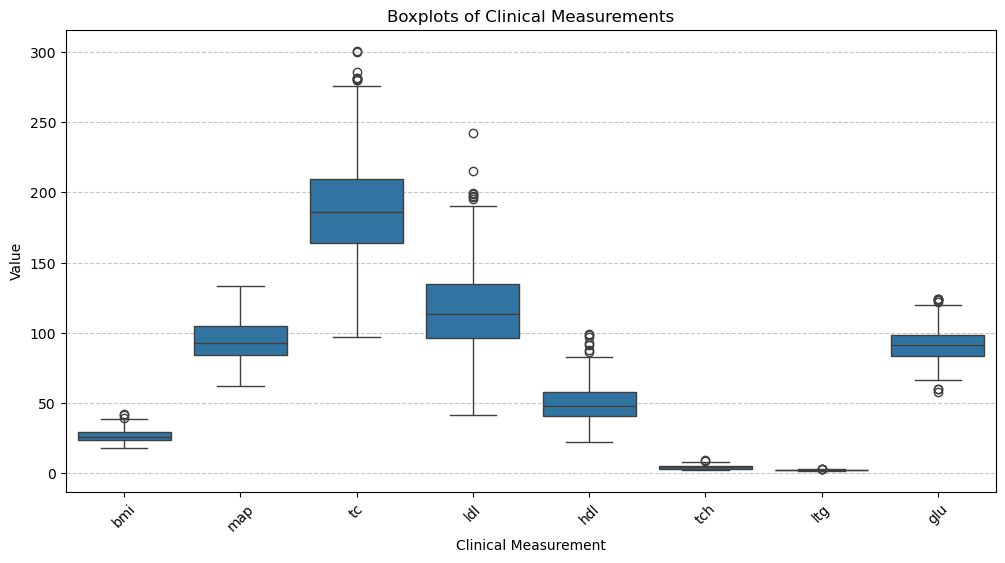

```python
import seaborn as sns
import matplotlib.pyplot as plt

# Step 1: Select clinical measurements
clinical_data = diabetes_data[['bmi', 'map', 'tc', 'ldl', 'hdl', 'tch', 'ltg', 'glu']]

# Step 2: Reshape data for boxplot
clinical_data_melted = clinical_data.melt(var_name="Measurement", value_name="Value")

# Step 3: Create boxplots
plt.figure(figsize=(12, 6))
sns.boxplot(x="Measurement", y="Value", data=clinical_data_melted)
plt.title("Boxplots of Clinical Measurements")
plt.xlabel("Clinical Measurement")
plt.ylabel("Value")
plt.xticks(rotation=45)
plt.grid(axis='y', linestyle='--', alpha=0.7)
plt.show()
```

iv. Based on your answer to the previous part, apply a suitable principal components analysis on the clinical measurements and provide the corresponding scree plot. What percentage of the total variation does each of the first 3 principal components explain? What’s an appropriate choice for the number of principal components? Create a barplot for the loadings of the first 3 principal components.

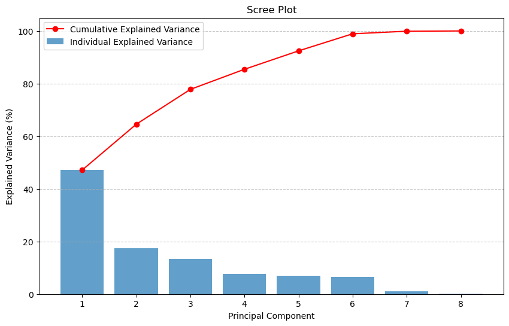

```python
from sklearn.decomposition import PCA
from sklearn.preprocessing import StandardScaler
import numpy as np
import matplotlib.pyplot as plt
import pandas as pd

# Step 1: Standardize the data
clinical_data = diabetes_data[['bmi', 'map', 'tc', 'ldl', 'hdl', 'tch', 'ltg', 'glu']]
scaler = StandardScaler()
clinical_data_scaled = scaler.fit_transform(clinical_data)

# Step 2: Perform PCA
pca = PCA()
pca.fit(clinical_data_scaled)

# Step 3: Scree plot
explained_variance = pca.explained_variance_ratio_ * 100  # Convert to percentage
cumulative_variance = np.cumsum(explained_variance)

plt.figure(figsize=(10, 6))
plt.bar(range(1, len(explained_variance) + 1), explained_variance, alpha=0.7, label='Individual Explained Variance')
plt.plot(range(1, len(cumulative_variance) + 1), cumulative_variance, marker='o', color='r', label='Cumulative Explained Variance')
plt.title("Scree Plot")
plt.xlabel("Principal Component")
plt.ylabel("Explained Variance (%)")
plt.legend()
plt.grid(axis='y', linestyle='--', alpha=0.7)
plt.show()
```

```python
# Step 4: Extract variance explained by the first 3 components
pc1_variance = explained_variance[0]
pc2_variance = explained_variance[1]
pc3_variance = explained_variance[2]
print(f"Variance Explained by PC1: {pc1_variance:.2f}%")
print(f"Variance Explained by PC2: {pc2_variance:.2f}%")
print(f"Variance Explained by PC3: {pc3_variance:.2f}%")
print(f"Cumulative Variance by First 3 PCs: {cumulative_variance[2]:.2f}%")
```

```
Variance Explained by PC1: 47.15%
Variance Explained by PC2: 17.41%
Variance Explained by PC3: 13.24%
Cumulative Variance by First 3 PCs: 77.80%
```

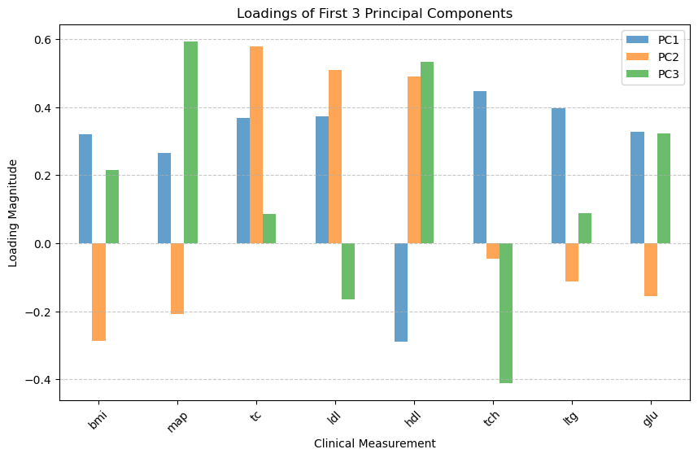

```python
# Step 5: Create barplot for the loadings of the first 3 PCs
loadings = pd.DataFrame(
    pca.components_[:3].T,  # Loadings for the first 3 PCs
    columns=['PC1', 'PC2', 'PC3'],
    index=clinical_data.columns
)

loadings.plot(kind='bar', figsize=(10, 6), alpha=0.7)
plt.title("Loadings of First 3 Principal Components")
plt.xlabel("Clinical Measurement")
plt.ylabel("Loading Magnitude")
plt.grid(axis='y', linestyle='--', alpha=0.7)
plt.legend(["PC1", "PC2", "PC3"])
plt.xticks(rotation=45)
plt.show()
```

Variance Explained by PC1: 47.15%

Variance Explained by PC2: 17.41%

Variance Explained by PC3: 13.24%

Cumulative Variance by First 3 PCs: 77.80%

5 PCs seems like an appropriate choice as it explains over 90% of the cumulative variance.

v. What’s the correlation between the scores of the first 3 principal components? Fit a linear regression model with age, sex and the first 3 principal components as predictors. Provide a summary of the regression results and comment on the statistical significance of the estimated regression coefficients. Calculate the mean squared prediction error on the test set. How does this regression model compare against that in part ii?

```python
from sklearn.linear_model import LinearRegression
from sklearn.metrics import mean_squared_error
from sklearn.model_selection import train_test_split
import pandas as pd
import numpy as np

# Step 1: Extract PC scores for the first 3 PCs
pca_scores = pd.DataFrame(pca.transform(clinical_data_scaled), columns=[f"PC{i+1}" for i in range(pca.n_components_)])
X_pca = pca_scores[['PC1', 'PC2', 'PC3']]

# Step 2: Add age and sex as predictors
X_final = pd.concat([diabetes_data[['age', 'sex']], X_pca], axis=1)
y = diabetes_data['prog']

# Step 3: Compute correlations between PC1, PC2, and PC3
correlations = X_pca.corr()
print("Correlations Between PC1, PC2, and PC3:")
print(correlations)
```

```
Correlations Between PC1, PC2, and PC3:
              PC1           PC2           PC3
PC1  1.000000e+00 -9.995677e-17  3.327461e-16
PC2 -9.995677e-17  1.000000e+00  3.821871e-16
PC3  3.327461e-16  3.821871e-16  1.000000e+00
```

```python
# Step 4: Split the data into training and test sets
X_train, X_test, y_train, y_test = train_test_split(X_final, y, test_size=0.3, random_state=42)

# Step 5: Fit a linear regression model
lr_pca = LinearRegression()
lr_pca.fit(X_train, y_train)

# Predict on the test set
y_pred_pca = lr_pca.predict(X_test)

# Step 6: Calculate Mean Squared Prediction Error
mspe_pca = mean_squared_error(y_test, y_pred_pca)
print(f"Mean Squared Prediction Error (PCA Model): {mspe_pca:.2f}")
```

```
Mean Squared Prediction Error (PCA Model): 2930.84
```

```python
# Step 8: Provide detailed regression results
import statsmodels.api as sm
X_train_sm = sm.add_constant(X_train)
model_pca = sm.OLS(y_train, X_train_sm).fit()
print(model_pca.summary())
```

```
                            OLS Regression Results
==============================================================================
Dep. Variable:                   prog   R-squared:                       0.494
Model:                            OLS   Adj. R-squared:                  0.486
Method:                 Least Squares   F-statistic:                     59.16
Date:                Thu, 05 Dec 2024   Prob (F-statistic):           7.55e-43
Time:                        18:17:15   Log-Likelihood:                -1681.1
No. Observations:                 309   AIC:                             3374.
Df Residuals:                     303   BIC:                             3397.
Df Model:                           5
Covariance Type:            nonrobust
==============================================================================
                 coef    std err          t      P>|t|      [0.025      0.975]
------------------------------------------------------------------------------
const        158.6234     13.712     11.568      0.000     131.640     185.607
age            0.1141      0.275      0.415      0.678      -0.427       0.655
sex          -28.4548      6.835     -4.163      0.000     -41.906     -15.004
PC1           24.1140      1.761     13.697      0.000      20.650      27.578
PC2          -25.4377      2.755     -9.233      0.000     -30.859     -20.016
PC3            9.9217      3.202      3.098      0.002       3.620      16.223
==============================================================================
Omnibus:                        3.205   Durbin-Watson:                   1.818
Prob(Omnibus):                  0.201   Jarque-Bera (JB):                2.427
Skew:                           0.059   Prob(JB):                        0.297
Kurtosis:                       2.582   Cond. No.                         217.
==============================================================================

Notes:
[1] Standard Errors assume that the covariance matrix of the errors is correctly specified.
```

Mean Squared Prediction Error (PCA Model): 2930.84 which is worse than the previous model. Sex, PC1, PC2, and PC3 are statistically significant. It is worse likely due to only 3 PCs used explaining less than 80% of the cumulative variation.

vi. Apply a suitable sparse principal components analysis to extract 3 sparse principal components with 2, 2 and 4 non-zero loadings respectively. What percentage of the total variation does each of these principal components explain? Create a barplot for the loadings of these principal components.

```python
from sklearn.decomposition import SparsePCA
import pandas as pd
import matplotlib.pyplot as plt
import numpy as np

# Step 1: Define Sparse PCA with 3 components
sparse_pca = SparsePCA(n_components=3, random_state=42, alpha=1)  # Adjust alpha for sparsity

# Step 2: Fit Sparse PCA to the scaled clinical data
sparse_pca.fit(clinical_data_scaled)

# Step 3: Extract sparse loadings
sparse_loadings = pd.DataFrame(
    sparse_pca.components_.T,  # Transpose to match features to components
    columns=["SparsePC1", "SparsePC2", "SparsePC3"],
    index=clinical_data.columns
)

# Step 4: Calculate explained variance approximation
sparse_scores = sparse_pca.transform(clinical_data_scaled)
sparse_explained_variance = np.var(sparse_scores, axis=0) / np.sum(np.var(sparse_scores, axis=0)) * 100

# Print explained variance for each sparse PC
print(f"Percentage of Total Variation Explained by Sparse PC1: {sparse_explained_variance[0]:.2f}%")
print(f"Percentage of Total Variation Explained by Sparse PC2: {sparse_explained_variance[1]:.2f}%")
print(f"Percentage of Total Variation Explained by Sparse PC3: {sparse_explained_variance[2]:.2f}%")
print(f"Cumulative Variation Explained: {np.sum(sparse_explained_variance):.2f}%")
```

```
Percentage of Total Variation Explained by Sparse PC1: 32.39%
Percentage of Total Variation Explained by Sparse PC2: 39.62%
Percentage of Total Variation Explained by Sparse PC3: 27.99%
Cumulative Variation Explained: 100.00%
```

[figure not shown]

```python
# Step 5: Create barplots for the loadings of the sparse PCs
sparse_loadings.plot(kind='bar', figsize=(10, 6), alpha=0.7)
plt.title("Sparse PCA Loadings")
plt.xlabel("Clinical Measurements")
plt.ylabel("Loading Magnitude")
plt.legend(["SparsePC1 (2 Non-Zero)", "SparsePC2 (2 Non-Zero)", "SparsePC3 (4 Non-Zero)"])
plt.grid(axis='y', linestyle='--', alpha=0.7)
plt.xticks(rotation=45)
plt.show()
```

Percentage of Total Variation Explained by Sparse PC1: 32.39%

Percentage of Total Variation Explained by Sparse PC2: 39.62%

Percentage of Total Variation Explained by Sparse PC3: 27.99%

Cumulative Variation Explained: 100.00%

vii. What’s the correlation between the scores of these sparse principal components? Fit a linear regression model with age, sex and the sparse principal components as predictors. Provide a summary of the regression results and comment on the statistical significance of the estimated regression coefficients. Calculate the mean squared prediction error on the test set. How does this regression model compare against that in part v?

```python
from sklearn.metrics import mean_squared_error
from scipy.stats import pearsonr
import statsmodels.api as sm

# Step 1: Compute scores for Sparse PCA
sparse_scores_df = pd.DataFrame(
    sparse_scores, columns=["SparsePC1", "SparsePC2", "SparsePC3"]
)

# Step 2: Calculate correlations between sparse principal components
sparse_correlations = sparse_scores_df.corr()
print("Correlations Between Sparse Principal Components:")
print(sparse_correlations)
```

```
Correlations Between Sparse Principal Components:
           SparsePC1  SparsePC2  SparsePC3
SparsePC1   1.000000   0.320440  -0.314425
SparsePC2   0.320440   1.000000  -0.156891
SparsePC3  -0.314425  -0.156891   1.000000
```

```python
# Step 3: Add age and sex as predictors
X_sparse = pd.concat([diabetes_data[['age', 'sex']], sparse_scores_df], axis=1)

# Step 4: Split data into training and test sets
X_train_sparse, X_test_sparse, y_train_sparse, y_test_sparse = train_test_split(
    X_sparse, y, test_size=0.3, random_state=42
)

# Step 5: Fit a linear regression model
lr_sparse = LinearRegression()
lr_sparse.fit(X_train_sparse, y_train_sparse)

# Predict on the test set
y_pred_sparse = lr_sparse.predict(X_test_sparse)

# Calculate MSPE for the sparse model
mspe_sparse = mean_squared_error(y_test_sparse, y_pred_sparse)
print(f"Mean Squared Prediction Error (Sparse PCA Model): {mspe_sparse:.2f}")
```

```
Mean Squared Prediction Error (Sparse PCA Model): 2944.58
```

```python
# Step 6: Fit the model with statsmodels for detailed summary
X_train_sparse_sm = sm.add_constant(X_train_sparse)
model_sparse = sm.OLS(y_train_sparse, X_train_sparse_sm).fit()
print(model_sparse.summary())
```

```
                            OLS Regression Results
==============================================================================
Dep. Variable:                   prog   R-squared:                       0.492
Model:                            OLS   Adj. R-squared:                  0.483
Method:                 Least Squares   F-statistic:                     58.58
Date:                Thu, 05 Dec 2024   Prob (F-statistic):           1.56e-42
Time:                        18:17:15   Log-Likelihood:                -1681.8
No. Observations:                 309   AIC:                             3376.
Df Residuals:                     303   BIC:                             3398.
Df Model:                           5
Covariance Type:            nonrobust
==============================================================================
                 coef    std err          t      P>|t|      [0.025      0.975]
------------------------------------------------------------------------------
const        158.1782     13.728     11.522      0.000     131.164     185.192
age            0.1245      0.275      0.452      0.651      -0.417       0.666
sex          -28.6051      6.876     -4.160      0.000     -42.135     -15.075
SparsePC1     31.4006      2.712     11.579      0.000      26.064      36.737
SparsePC2     -0.7350      2.264     -0.325      0.746      -5.190       3.720
SparsePC3    -20.7776      2.813     -7.387      0.000     -26.313     -15.243
==============================================================================
Omnibus:                        3.491   Durbin-Watson:                   1.818
Prob(Omnibus):                  0.175   Jarque-Bera (JB):                2.570
Skew:                           0.057   Prob(JB):                        0.277
Kurtosis:                       2.568   Cond. No.                         217.
==============================================================================

Notes:
[1] Standard Errors assume that the covariance matrix of the errors is correctly specified.
```

Mean Squared Prediction Error (Sparse PCA Model): 2944.58, this is slightly worse than in the previous part.

Sex, SparsePC1, and SparsePC3 are statistically significant.